# Тестирование статистических гипотез

## ЧАСТЬ 1. Tеория

## Сравнение выборок

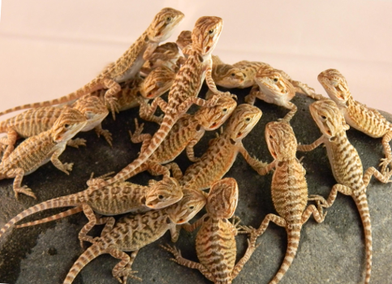

[figure not shown]

Различия между выборками не всегда видны невооружённым глазом.

## Гипотезы: нулевая и альтернативная

Первый шаг в сравнении – формулировка нулевой гипотезы.

Положение H0 привилегированное: именно ее мы тестируем, принимаем или отвергаем.

Чаще всего она формулируется как **отсутствие различий** между сравниваемыми объектами. Например: ящерицы из двух популяций одинаково крупные.

Вместе с нулевой гипотезой рождается на свет и альтернативная гипотеза.

В общем виде, она формулируется как **присутствие различий** и включает все частные случаи, например “размеры ящериц из двух популяций неодинаковы”.

## Гипотезы: нулевая и альтернативная

Решение о том, принять или отвергнуть H0 мы принимаем после статистического теста. Но результат теста не тождественен реальному состоянию дел - он не скажет, верна ли H0, только укажет, как с ней поступить.

Вне зависимости от нас, реальность может находиться в одном из двух состояний: H0 верна, ящерицы одинаковы, либо H0 неверна, и ящерицы различаются.

Таким образом, возможно четыре исхода теста.

В мире где ящерицы одинаковы мы можем

- принять H0 (и это будет верное решение),
- либо отвергнуть ее (и это будет ошибка).

Аналогично, в мире где ящерицы различаются, мы можем

- принять H0 (что ошибочно),
- либо отвергнуть ее (что верно).

## Верные и неверные решения

|  | H0 == TRUE | H0 == FALSE |
| --- | --- | --- |
| Отклонить H0 | Ошибка I рода с вероятностью α Ложно-положительный результат | Верно |
| Сохранить H0 | Верно | Ошибка II рода с вероятностью β Ложно-отрицательный результат |

## Верные и неверные решения

**Ошибка I рода: нашли то, чего нет**

**Ошибка II рода: пропустили то, что было**

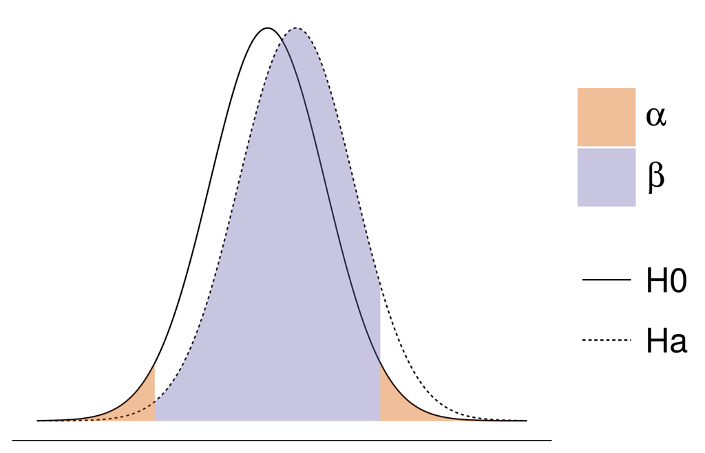

## Ошибки

Вероятность ошибки I рода мы задаем сами — это уровень значимости теста, \(\alpha\). Это та вероятность, меньше которой мы отказываемся верить в справедливость H0.

Ошибка второго рода обычно скрыта. Но ее можно уменьшить вслепую, например увеличив объем выборки.

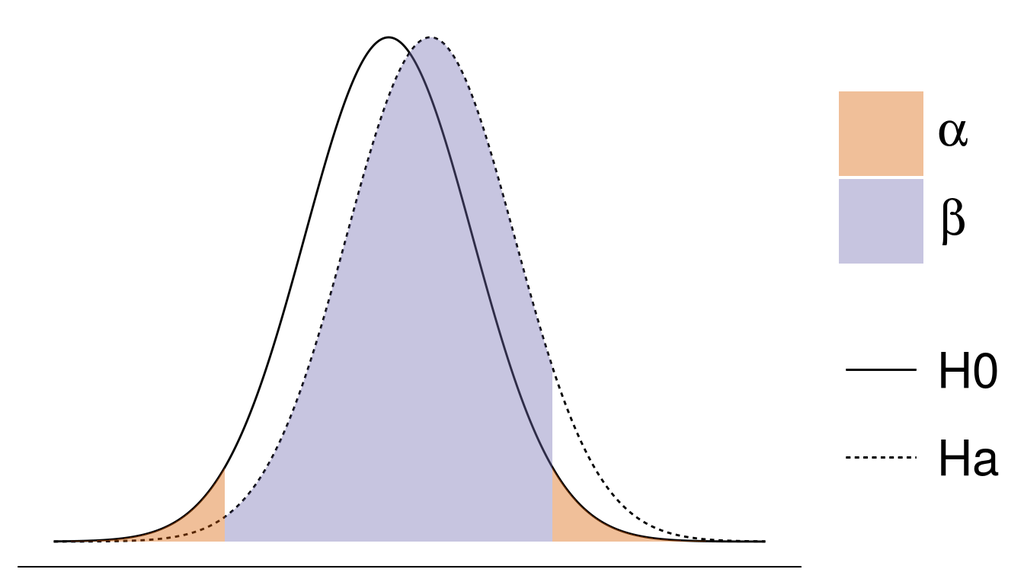

## Как принять решение?

### Статистические таблицы

Принцип прост – мы вычисляем **эмпирическое** значение тестовой статистики, и сравниваем его с **критическим** значением этой же статистики из таблицы.

Т.е. мы сравниваем тестовую статистику с тестовой статистикой: t-критерий с t-критерием, \(\chi^2\) с \(\chi^2\).

### P-value

Принятие решения на основании p-value стало возможным когда стали доступны большие вычислительные мощности.

P-value отражает вероятность обнаружить тот уровень различий между выборками который мы видим, при условии что H0 верна.

Если р велико, мы решаем что выборки принципиально одинаковы, если мало - что выборки принципиально различаются.

Принимая решение на основании p-value мы сравниваем ее с уровнем значимости \(\alpha\), т.е. сравниваем вероятность с вероятностью.

## P-value. Ещё раз, другими словами

Допустим, мы сравнили выборки и получили р = 0.03

P-value = 0.03 не значит, что H0 верна с вероятностью 3%!

P-value = 0.03 значит, что в мире, где выборки одинаковы а H0 верна, шанс получить результат который мы получили составляет 3%.

Уже мы сами решаем, кажется ли нам такая вероятность приемлемой.

## ЧАСТЬ 2. В сердце статистического теста

## Шаг назад. Cтандартизация

Из эмпирического распределения *X* создадим распределение *Z*, где каждое значение \(x_i\) будет заменено на \(z_i\).

1. Выполним центрирование. Для этого заменим значения переменной на девиаты: \(x_i - \bar{x}\)
2. Нормируем разброс. Для этого разделим девиаты на стандартное отклонение выборки.

\[z_i=\frac{x_i - \bar{x}}{SD}\]

## После стандартизации всегда:

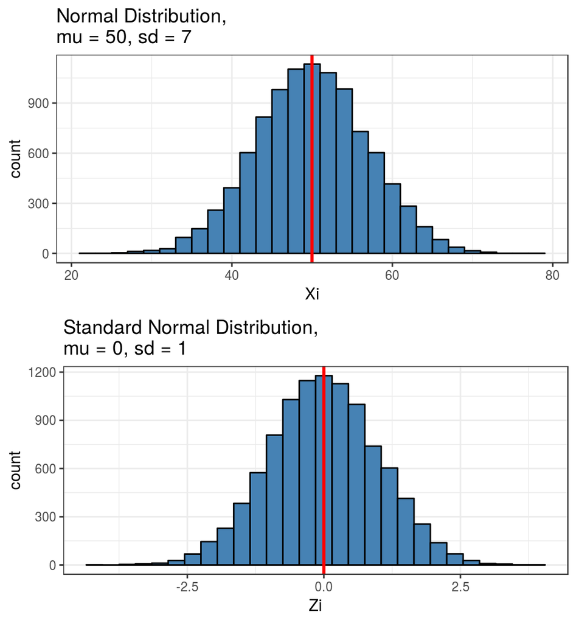

- среднее \(\mu = 0\)
- стандартное отклонение \(\sigma = 1\)

## Операции с распределениями

Давайте познакомимся с тремя полезными функциями для работы с распределениями: `r, q, p`

### r = random number generation.

С помощью этой функции можно смоделировать взятие выборки из генеральной совокупности с заданными параметрами.

Например: `rnorm(1000, mean = 20, sd = 2)` сгенерирует выборку в 1000 случайных значений из нормального распределения.

### q = quantile function.

С ее помощью можно получить квантиль (точнее персентиль) - то значение переменной, которое отсекает заданную часть распределения.

Например: `qnorm(0.5, mean = 20, sd = 2)` вернет среднюю, т.к. ровно 50% значений в нормальном распределении \(< \mu\)

`qnorm(0.025, mean = 20, sd = 2)` вернет то значение X, которое делит распределение на куски в 2.5% и 97.5%, т.е. 2.5% всех значений будут меньше, а 97.5% - больше него.

## Задание

С помощью функции `qnorm` получите 5-number summary для распределения с параметрами \(\mu\) = 3 и \(\sigma\) = 5

## Решение

Для 5-number summary нам нужны минимальное и максимальное значение, медиана, I и III квантили.

Создадим вектор

```r
five_numbers <- c(0, 0.25, 0.5, 0.75, 1)
```

и передадим его функции `qnorm`

```r
qnorm(five_numbers, 3, 5)
```

```
## [1]   -Inf -0.372  3.000  6.372    Inf
```

## Операции с распределениями

### p = probability distribution function

С ее помощью можно рассчитать вероятность того, что случайная величина, взятая из данного распределения, окажется меньше заданного нами значения.

Эта операция принципиально обратна тому, что делает `q`.

Например: `pnorm(20, mean = 20, sd = 2)` вернет вероятность 0.5, или 50%, поскольку мы передали ей в качестве аргумента среднюю

Эта функция работает кумулятивно:

```r
round(pnorm(c(0, 15, 20, 25, 40), 20, 2), 3)
```

```
## [1] 0.000 0.006 0.500 0.994 1.000
```

## t-статистика

\[t=\frac{d}{SE_d}\]

- \(d=\bar{x_1} - \bar{x_2}\) - это разность между двумя средними значениями
- \(SE_d\) - Общее среднеквадратичное отклонение разности двух средних

\[SE_d = \sqrt{\frac{sd_1^2(n_1-1) +sd_2^2(n_2-1)}{n_1+n_2-2}(\frac{1}{n_1} + \frac{1}{n_2})}\]

Если \(n_1 = n_2\), то формула существенно упрощается

\[SE_d = \sqrt{\frac {sd_1^2} {n_1} + \frac {sd_2^2} {n_2}}\]

Таким образом, t-распределение это стандартизованное распределение разностей двух средних значений из одной генеральной совокупности

## t-распределение

Распределение t-статистики описывает заковыристая функция. Нам нужно знать про нее один важный факт: форма распределения зависит от единственного параметра \(df\) - числа степеней свободы.

\[df = n_1 + n_2 - 2\]

Давайте посмотрим, как выглядят распределения с разными df:

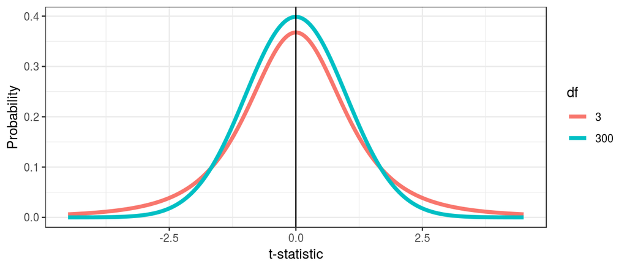

## ЧАСТЬ 3. Применение t-теста

## Пример t-теста

Давайте выполним t-тест и решим, как нам поступить с нулевой гипотезой (для этого нам пригодятся операции `qt` и `pt`)

Для начала создадим две выборки длин ящериц из популяций Берлина и Саратова. В этих гипотетических выборках длины распределены нормально, и имеют заведомо отличающимися \(\mu\)

```r
# Зерно для генератора случайных чисел для сопоставимости результатов
set.seed(456)
# Создаем две выборки по 100 из нормального распределения с разными параметрами
Saratov <- rnorm(n = 100, mean = 130, sd = 5)
Berlin <- rnorm(n = 100, mean = 129, sd = 5)
city <- c(rep("B", 100), rep("S", 100))
# Сохраняем выборки в датафрейме для удобства
lizards <- data.frame(city = factor(city),
                        length = c(Berlin, Saratov))


head(lizards)
```

```
##   city length
## 1    B    130
## 2    B    133
## 3    B    129
## 4    B    129
## 5    B    121
## 6    B    135
```

## Построим частотные распределения этих выборок

```r
library(ggplot2) # Загрузим библиотеку
theme_set(theme_bw()) # Зададим тему
```

Сконструируем “скелет” графика

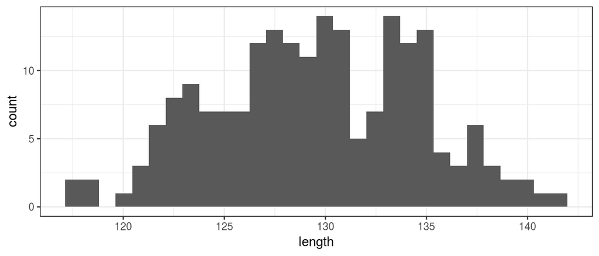

```r
ggplot(lizards, aes(x = length)) +
  geom_histogram()
```

## Изменим ширину интервалов гистограммы

Здесь ящерицы из разных мест пока еще смешаны.

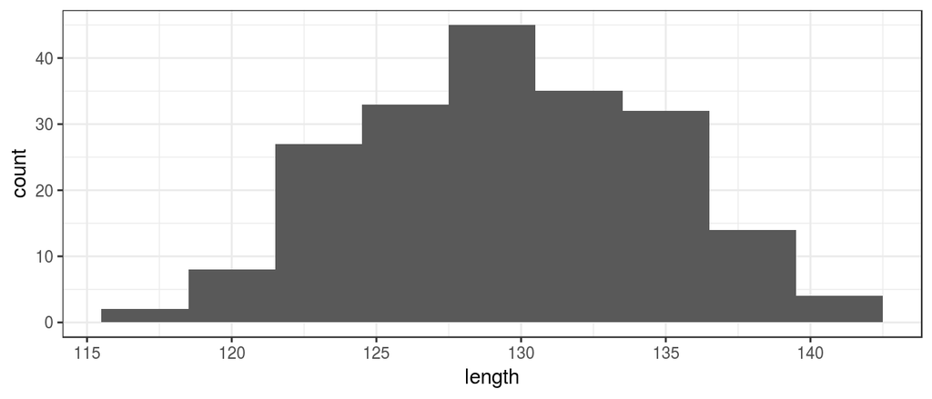

```r
ggplot(lizards, aes(x = length)) +
  geom_histogram(binwidth = 3)
```

## Разделим столбцы гистограммы по признаку city и сохраним в новую переменную

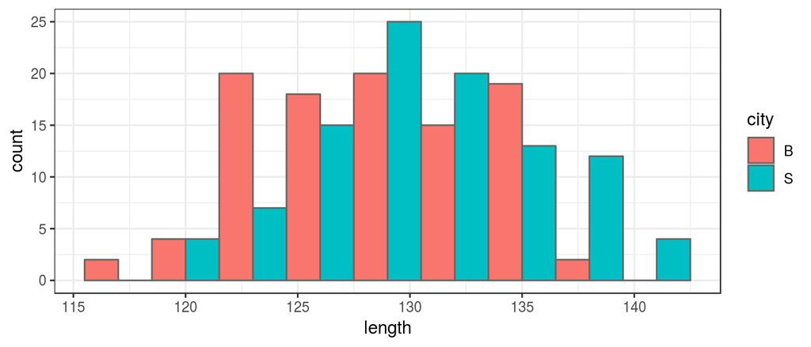

```r
gg_length <- ggplot(lizards, aes(x = length, fill = city)) +
    geom_histogram(binwidth = 3, colour = "grey40", position = "dodge")
gg_length
```

## Добавим подписи осей и заголовок

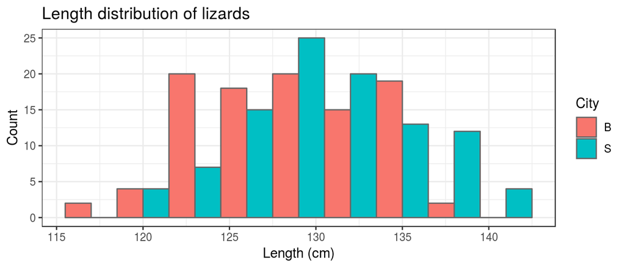

```r
gg_length +
  labs(x = "Length (cm)",
       y = "Count",
       title ="Length distribution of lizards",
       fill = "City")
```

### Наш график готов!

## Выполним t-тест

```r
t_lizards <- t.test(data = lizards, length ~ city)
# length ~ city показывает, что значения переменной
# length сгруппированы по признаку city
# Порядок записи важен!
t_lizards
```

```
##
##  Welch Two Sample t-test
##
## data:  length by city
## t = -3, df = 200, p-value = 0.002
## alternative hypothesis: true difference in means is not equal to 0
## 95 percent confidence interval:
##  -3.562 -0.811
## sample estimates:
## mean in group B mean in group S
##             128             131
```

## Основные результаты

`t_lizards` это комплексный объект, который можно изучить с помощью функции `str()`

Нас интересуют две переменные: значение тестовой t-статистики

```r
t_value_lizards <- t_lizards$statistic
t_value_lizards
```

```
##     t
## -3.13
```

и итоговое p-value

```r
p_value_lizards <- t_lizards$p.value
p_value_lizards
```

```
## [1] 0.00199
```

## Достоверны ли различия? Смотрим в “таблицу”

Рассчитаем “табличное” значение t-критерия с помощью функции `qt()`

- так как критерий двухсторонний, мы должны разбить 5% на два кусочка по 2.5%, т.е. `p = c(0.025, 0.975)`
- число степеней свободы \(n_1 + n_2 - 2\) равно `100 + 100 - 2 = 198`

Подставим эти аргументы:

```r
qt(p = c(0.025, 0.975), 198)
```

```
## [1] -1.97  1.97
```

Теперь с этими критическими значениями можно сравнить эмпирический результат:

```r
t_value_lizards
```

```
##     t
## -3.13
```

## Достоверны ли различия? Сравниваем вероятности

С помощью команды `pt()` определим вероятность того, что случайная величина, взятая из t-распределения, окажется меньше рассчитанной нами t-статистики

```r
pt(t_value_lizards, df = 198)
```

```
##        t
## 0.000994
```

### Это “сырая” величина. Её еще нельзя сравнивать с уровнем значимости.

Мы должны либо умножить p.value на 2, либо поделить \(\alpha\) пополам, и только после этого сравнивать их.

```r
p.value <- 2 * pt(t_value_lizards, df = 198)
p.value
```

```
##       t
## 0.00199
```

Этот результат совпадает с тем, что рассчитал t-тест

### Вопрос: Вероятность какого события отражает p=0.002?

## Уровень значимости p=0.002

Иными словами:

Это НЕ вероятность того, что H0 верна.

Это вероятность того, что в мире, где H0 верна, а длины ящериц из Берлина и Саратова равны, шанс получить эмпирические выборки с такими различиями как у нас, составляет 0.2%.

Кстати, какова разница между средними длинами в наших выборках?

## Допущения (Assumptions) двухвыборочного t-критерия

- Независимость выборок друг от друга
- Независимость наблюдений внутри групп
- Нормальное распределение сравниваемых величин (если выборки малы, n < 30)
- Равенство дисперсий (можно нарушать, требуется коррекция по методу Велча)

## Задание

Файл `2.2_aml.csv` содержит данные о влиянии регулярной химиотерапии на продолжительность ремиссии.

Прочитаем эти данные

```r
rem <- read.csv("data/2.2_aml.csv", header = T)
str(rem)
```

```
## 'data.frame':    23 obs. of  2 variables:
##  $ time : int  9 13 13 18 23 28 31 34 45 48 ...
##  $ group: int  1 1 1 1 1 1 1 1 1 1 ...
```

- В переменной `time` представлена продолжительность ремиссии в днях.
- `group` указывает, к какой экспериментальной группе принадлежал пациент. В группе 1 проводилась регулярная химиотерапия, в группе 2 - нет.

Ваша задача сравнить эти группы с помощью t-теста.

## Проверяем условия применимости

```r
library(car)
par(mfrow = c(1, 2))
qqPlot(rem$time[rem$group == 1])
```

```
## [1] 11  1
```

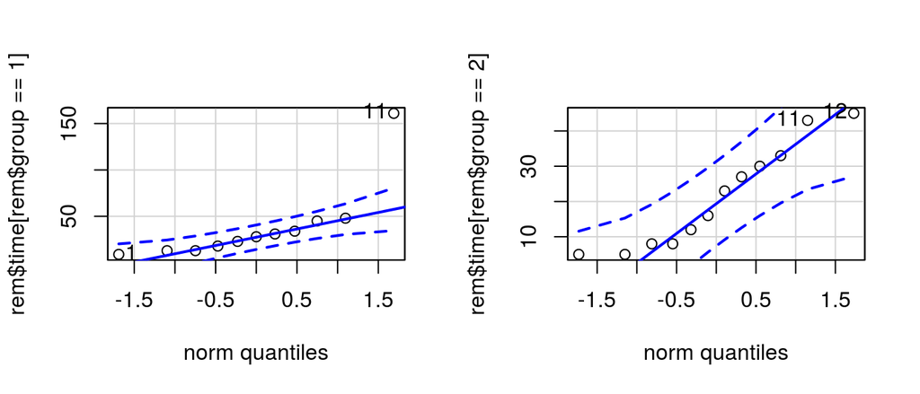

```
## [1] 12 11
```

```r
qqPlot(rem$time[rem$group == 2])
```

```r
par(mfrow = c(1, 1))
```

Есть выброс, хорошо бы проверить это наблюдение.

## Решение

```r
rem1 <- rem[rem$time < 150, ] # исключаем выброс
t.test(data = rem1, time ~ group)
```

```
##
##  Welch Two Sample t-test
##
## data:  time by group
## t = 0.8, df = 20, p-value = 0.4
## alternative hypothesis: true difference in means is not equal to 0
## 95 percent confidence interval:
##  -7.49 17.39
## sample estimates:
## mean in group 1 mean in group 2
##            26.2            21.2
```

Или так:

```r
t.test(rem1$time[rem1$group==1], rem1$time[rem1$group==2])
```

## Напоследок

## Статистическая значимость

Статистическая значимость бывает только одна и она говорит о том, в каких отношениях состоят обнаруженные нами эмпирически различия с \(\alpha\).

Если мы отвергаем H0, имеются различия.

Если мы не отвергаем H0, все одинаково.

Пожалуйста, никаких недостоверных различий! Если различия есть, то они достоверны. Если различия не достоверны, то их нет.

А что делать, если сердцем чувствуешь, что что-то должно быть, но тест не дает нужного ответа? Собрать выборки побольше, и посчитать заново. С уже проведенным тестом спорить не надо.